# Data Analysis 6 by Eric Braun

```
##    Min. 1st Qu.  Median    Mean 3rd Qu.    Max.
##   0.000   0.090   0.260   0.271   0.420   1.000
```

Citric acid is sometimes considered a fixed acid. It is present in trace amounts in grapes, but is often added for flavor. The EU prohibits this usage, but it can be used there to remove minerals from the wine. We don’t see a simple bell curve. The basic shape is decreasing quantities with a number of peaks.  
The minimum is 0, which is odd and suggestive of incomplete data, the maximum is 1. The median is .26 and the mean is .271. The quartiles are .09 and .42.

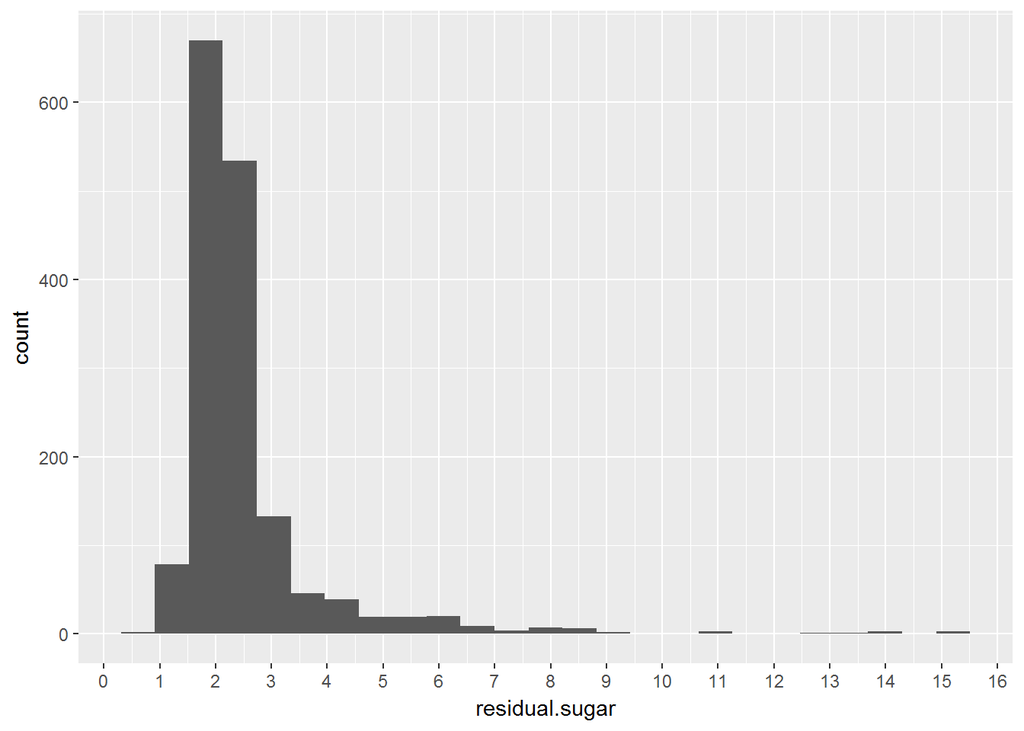

```
##    Min. 1st Qu.  Median    Mean 3rd Qu.    Max.
##   0.900   1.900   2.200   2.539   2.600  15.500
```

The next variable is residual sugar. Fermentation is the process of converting sugar to alcohol, but not all the sugar is converted. The left over sugar determines the dryness of the wine. Dry reds have 2-3 grams per liter while sweeter reds can have as much as 30. We can see that most of the wine in this set is dry, with the majority of the sample at 2-3.  
The minimum value is .9 and the max is 15.5. The median is 2.2 and the mean is 2.539. The quartiles are 1.9 and 2.6.

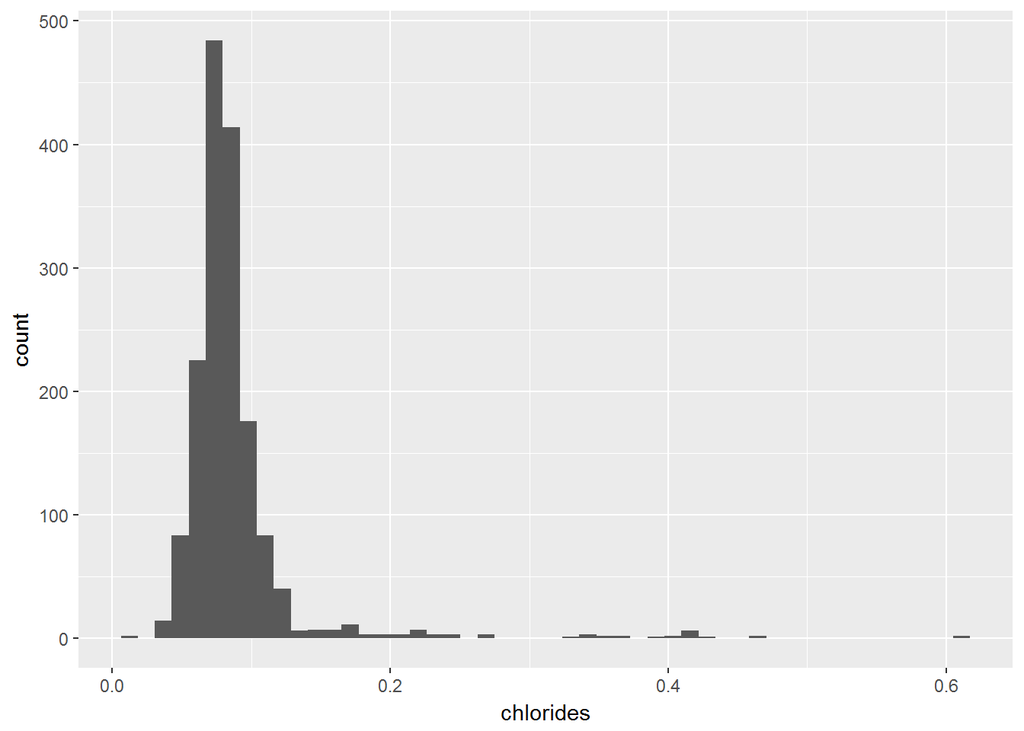

```
##    Min. 1st Qu.  Median    Mean 3rd Qu.    Max.
## 0.01200 0.07000 0.07900 0.08747 0.09000 0.61100
```

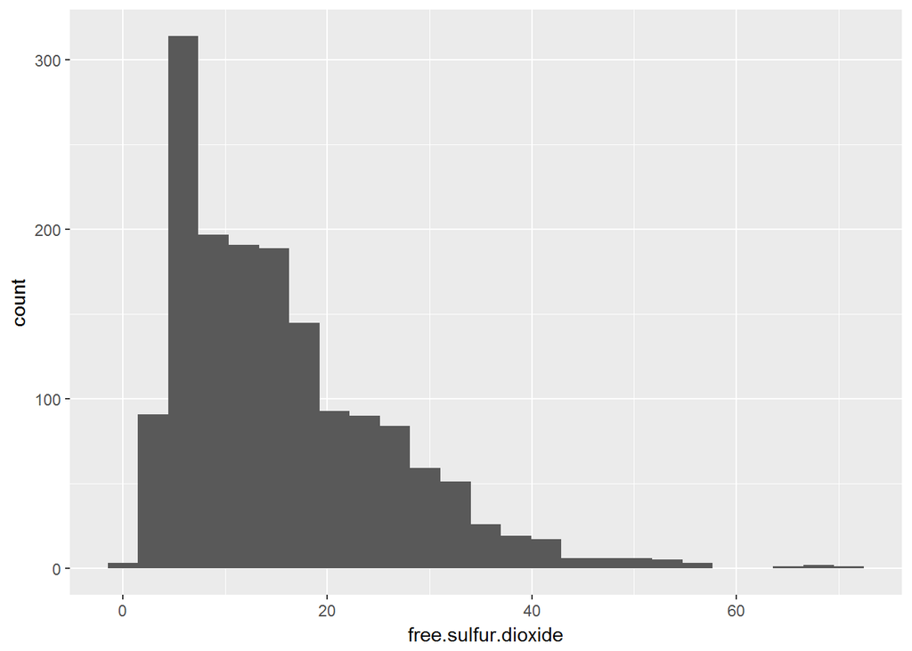

```
##    Min. 1st Qu.  Median    Mean 3rd Qu.    Max.
##    1.00    7.00   14.00   15.87   21.00   72.00
```

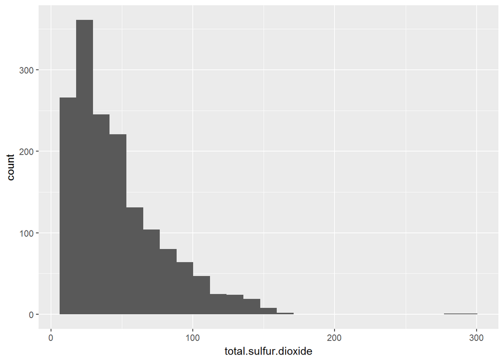